# Power Analysis: Non-inferiority Cluster Randomised Trial

# Power with ICC

With n=292 where we compute the power, we vary the effect size from 1.5, 1.6, 1.7; vary the intraclass correlation in the treatment group from 0.2, 0.25, 0.3; and vary the levels of outcome in the control arm from 0.2, 0.3, 0.4.

- n_total: Total number of participants
- n_0 & n_1: Number of participants on individual PrEP arm and group PrEP arm
- rho_0 & rho_1: ICC assumption on individual PrEP arm and group PrEP arm
- deff_0 & deff_1: Design effect
- n_0_s & n_1_s: Sample size under individual randomization
- pi_0: Proportion assumption for the individual PrEP arm
- RR: Relative risk
- Power

```r
m <- 3
n_0 <- 124
n_1 <- 168
n_total <- n_0 + n_1
pi_0 <- c(0.2,0.3,0.4)
RR <- c(1.5,1.6,1.7)
rho_0 <- 0.05
rho_1 <- c(0.2,0.25,0.3)

grd <- as.data.frame(expand.grid(RR,pi_0,rho_0,rho_1))
colnames(grd) <- c("RR","pi_0","rho_0","rho_1")
grd <- grd[order(grd$RR,grd$pi_0,grd$rho_0,grd$rho_1),]

RR <- grd$RR
pi_0 <- grd$pi_0
rho_0 <- grd$rho_0
rho_1 <- grd$rho_1

deff_0 <- 1 + (m-1)*rho_0
deff_1 <- 1 + (m-1)*rho_1

pi_1 <- pi_0*RR

n_0_s <- floor(n_0/deff_0)
n_1_s <- floor(n_1/deff_1)

z <- (pi_1 - pi_0)/sqrt((pi_1*(1-pi_1)/n_1_s + pi_0*(1-pi_0)/n_0_s))
z <- abs(z)

alpha <- .05
Z_a <- qnorm(1-alpha/2)

Power <- pnorm(-Z_a + z) + pnorm(-Z_a - z)
RowNumber <- 1:length(Power)
Power1 <- as.data.frame(cbind(RowNumber,n_total
                              ,RR,pi_0
                              ,n_0,rho_0,deff_0,n_0_s
                              ,n_1,rho_1,deff_1,n_1_s
                              ,Power))

knitr::kable(
  Power1
  ,digits = 2
)
```

| RowNumber | n_total | RR | pi_0 | n_0 | rho_0 | deff_0 | n_0_s | n_1 | rho_1 | deff_1 | n_1_s | Power |
| --- | --- | --- | --- | --- | --- | --- | --- | --- | --- | --- | --- | --- |
| 1 | 292 | 1.5 | 0.2 | 124 | 0.05 | 1.1 | 112 | 168 | 0.20 | 1.4 | 120 | 0.43 |
| 2 | 292 | 1.5 | 0.2 | 124 | 0.05 | 1.1 | 112 | 168 | 0.25 | 1.5 | 112 | 0.41 |
| 3 | 292 | 1.5 | 0.2 | 124 | 0.05 | 1.1 | 112 | 168 | 0.30 | 1.6 | 105 | 0.40 |
| 4 | 292 | 1.5 | 0.3 | 124 | 0.05 | 1.1 | 112 | 168 | 0.20 | 1.4 | 120 | 0.67 |
| 5 | 292 | 1.5 | 0.3 | 124 | 0.05 | 1.1 | 112 | 168 | 0.25 | 1.5 | 112 | 0.65 |
| 6 | 292 | 1.5 | 0.3 | 124 | 0.05 | 1.1 | 112 | 168 | 0.30 | 1.6 | 105 | 0.64 |
| 7 | 292 | 1.5 | 0.4 | 124 | 0.05 | 1.1 | 112 | 168 | 0.20 | 1.4 | 120 | 0.87 |
| 8 | 292 | 1.5 | 0.4 | 124 | 0.05 | 1.1 | 112 | 168 | 0.25 | 1.5 | 112 | 0.86 |
| 9 | 292 | 1.5 | 0.4 | 124 | 0.05 | 1.1 | 112 | 168 | 0.30 | 1.6 | 105 | 0.85 |
| 10 | 292 | 1.6 | 0.2 | 124 | 0.05 | 1.1 | 112 | 168 | 0.20 | 1.4 | 120 | 0.56 |
| 11 | 292 | 1.6 | 0.2 | 124 | 0.05 | 1.1 | 112 | 168 | 0.25 | 1.5 | 112 | 0.54 |
| 12 | 292 | 1.6 | 0.2 | 124 | 0.05 | 1.1 | 112 | 168 | 0.30 | 1.6 | 105 | 0.53 |
| 13 | 292 | 1.6 | 0.3 | 124 | 0.05 | 1.1 | 112 | 168 | 0.20 | 1.4 | 120 | 0.82 |
| 14 | 292 | 1.6 | 0.3 | 124 | 0.05 | 1.1 | 112 | 168 | 0.25 | 1.5 | 112 | 0.80 |
| 15 | 292 | 1.6 | 0.3 | 124 | 0.05 | 1.1 | 112 | 168 | 0.30 | 1.6 | 105 | 0.79 |
| 16 | 292 | 1.6 | 0.4 | 124 | 0.05 | 1.1 | 112 | 168 | 0.20 | 1.4 | 120 | 0.96 |
| 17 | 292 | 1.6 | 0.4 | 124 | 0.05 | 1.1 | 112 | 168 | 0.25 | 1.5 | 112 | 0.96 |
| 18 | 292 | 1.6 | 0.4 | 124 | 0.05 | 1.1 | 112 | 168 | 0.30 | 1.6 | 105 | 0.95 |
| 19 | 292 | 1.7 | 0.2 | 124 | 0.05 | 1.1 | 112 | 168 | 0.20 | 1.4 | 120 | 0.68 |
| 20 | 292 | 1.7 | 0.2 | 124 | 0.05 | 1.1 | 112 | 168 | 0.25 | 1.5 | 112 | 0.67 |
| 21 | 292 | 1.7 | 0.2 | 124 | 0.05 | 1.1 | 112 | 168 | 0.30 | 1.6 | 105 | 0.65 |
| 22 | 292 | 1.7 | 0.3 | 124 | 0.05 | 1.1 | 112 | 168 | 0.20 | 1.4 | 120 | 0.92 |
| 23 | 292 | 1.7 | 0.3 | 124 | 0.05 | 1.1 | 112 | 168 | 0.25 | 1.5 | 112 | 0.91 |
| 24 | 292 | 1.7 | 0.3 | 124 | 0.05 | 1.1 | 112 | 168 | 0.30 | 1.6 | 105 | 0.90 |
| 25 | 292 | 1.7 | 0.4 | 124 | 0.05 | 1.1 | 112 | 168 | 0.20 | 1.4 | 120 | 0.99 |
| 26 | 292 | 1.7 | 0.4 | 124 | 0.05 | 1.1 | 112 | 168 | 0.25 | 1.5 | 112 | 0.99 |
| 27 | 292 | 1.7 | 0.4 | 124 | 0.05 | 1.1 | 112 | 168 | 0.30 | 1.6 | 105 | 0.99 |

# Matched Pair Design

Individual-Randomization
$$n_I=\frac{(z_{\alpha/2}+z_\beta)^2(\pi_0(1-\pi_0)+\pi_1(1-\pi_1))}{(\pi_0-\pi_1)^2}$$

Design Effect
$$Deff=1+(m-1)\rho$$

Relationship between ICC and Coefficient of Variance (k)
$$\rho = \frac{k^2\pi}{1-\pi}$$

Matched-Pair Cluster-Randomization
$$c_m=2 + (z_{\alpha/2} + z_{\beta})^2\frac{\pi_0(1-\pi_0)/m + \pi_1(1-\pi_1)/m + k_m^2(\pi_0^2 + \pi_1^2)}{(\pi_0-\pi_1)^2}$$

Reference: Richard J. Hayes, Lawrence H. Moulton. Cluster Randomised Trials, 2nd Edition. Chapman & Hall/CRC Biostatistics Series

```r
## given 14 pairs and 27 patients per cluster
## given .65 on SOC arm
## power for RR from 1.2 to 1.3, on ICC of 0.03,0.05,0.07
p1 <- 0.65
rr <- seq(1.2,1.4,0.02)
c <- c(14)
n <- 27
icc <- c(0.03,0.05,0.07)
df <- expand.grid(n,p1,rr,c,icc)
df <- as.data.table(as.data.frame(df))
colnames(df) <- c("n","p1","rr","c","icc")

# k is calculated on p1
df <- df[
  ,p2 := p1*rr
][p2 < 0.98
][,k := sqrt(icc*(1-p1)/p1)
][,alpha := 0.05
][,z_alpha := qnorm(1-alpha/2)
][,z_beta := sqrt((c - 2)*(p1-p2)^2/(p1*(1-p1)/n + p2*(1-p2)/n + k^2*(p1^2 + p2^2))) - z_alpha
][z_beta > 0
][,power:= pnorm(z_beta)
][,ni := (qnorm(1-0.05/2) + qnorm(0.8))^2*(p1*(1-p1) + p2*(1-p2))/(p1-p2)^2
][,deff := n*c/ni
][,deff2 := 2 + icc*(n-1)
# ][power >= 0.8
# ][,diff := power - 0.8
# ][order(c,n,p1,rr,icc,abs(diff))
# ][,rnb := 1:.N,by=list(c,n,p1,rr,icc)
# ][rnb == 1
][order(rr,icc)
# ][,rnb2 :=1:.N,by=list(c,p1,rr,icc)
# ][rnb2 == 1
# ][order(p1,rr,icc,n,c)
][,rn:=1:.N]

# View(df) dim(df)
knitr::kable(
  df[,list(rn,c,n,p1,rr,p2,icc,power)]
  ,col.names = c("#","Matched Pairs","Patients per Clinic","Rate on SOC", "RR","Rate on TRT", "ICC","Power")
  ,digits = c(0,0,0,2,2,2,3,3,1)
  ,caption = "Sample Size and Power"
)
```

Sample Size and Power

| # | Matched Pairs | Patients per Clinic | Rate on SOC | RR | Rate on TRT | ICC | Power |
| --- | --- | --- | --- | --- | --- | --- | --- |
| 1 | 14 | 27 | 0.65 | 1.20 | 0.78 | 0.03 | 0.719 |
| 2 | 14 | 27 | 0.65 | 1.20 | 0.78 | 0.05 | 0.588 |
| 3 | 14 | 27 | 0.65 | 1.22 | 0.79 | 0.03 | 0.797 |
| 4 | 14 | 27 | 0.65 | 1.22 | 0.79 | 0.05 | 0.668 |
| 5 | 14 | 27 | 0.65 | 1.22 | 0.79 | 0.07 | 0.567 |
| 6 | 14 | 27 | 0.65 | 1.24 | 0.81 | 0.03 | 0.861 |
| 7 | 14 | 27 | 0.65 | 1.24 | 0.81 | 0.05 | 0.740 |
| 8 | 14 | 27 | 0.65 | 1.24 | 0.81 | 0.07 | 0.638 |
| 9 | 14 | 27 | 0.65 | 1.26 | 0.82 | 0.03 | 0.909 |
| 10 | 14 | 27 | 0.65 | 1.26 | 0.82 | 0.05 | 0.803 |
| 11 | 14 | 27 | 0.65 | 1.26 | 0.82 | 0.07 | 0.703 |
| 12 | 14 | 27 | 0.65 | 1.28 | 0.83 | 0.03 | 0.944 |
| 13 | 14 | 27 | 0.65 | 1.28 | 0.83 | 0.05 | 0.855 |
| 14 | 14 | 27 | 0.65 | 1.28 | 0.83 | 0.07 | 0.762 |
| 15 | 14 | 27 | 0.65 | 1.30 | 0.85 | 0.03 | 0.967 |
| 16 | 14 | 27 | 0.65 | 1.30 | 0.85 | 0.05 | 0.897 |
| 17 | 14 | 27 | 0.65 | 1.30 | 0.85 | 0.07 | 0.814 |
| 18 | 14 | 27 | 0.65 | 1.32 | 0.86 | 0.03 | 0.982 |
| 19 | 14 | 27 | 0.65 | 1.32 | 0.86 | 0.05 | 0.929 |
| 20 | 14 | 27 | 0.65 | 1.32 | 0.86 | 0.07 | 0.857 |
| 21 | 14 | 27 | 0.65 | 1.34 | 0.87 | 0.03 | 0.990 |
| 22 | 14 | 27 | 0.65 | 1.34 | 0.87 | 0.05 | 0.953 |
| 23 | 14 | 27 | 0.65 | 1.34 | 0.87 | 0.07 | 0.893 |
| 24 | 14 | 27 | 0.65 | 1.36 | 0.88 | 0.03 | 0.995 |
| 25 | 14 | 27 | 0.65 | 1.36 | 0.88 | 0.05 | 0.970 |
| 26 | 14 | 27 | 0.65 | 1.36 | 0.88 | 0.07 | 0.922 |
| 27 | 14 | 27 | 0.65 | 1.38 | 0.90 | 0.03 | 0.998 |
| 28 | 14 | 27 | 0.65 | 1.38 | 0.90 | 0.05 | 0.981 |
| 29 | 14 | 27 | 0.65 | 1.38 | 0.90 | 0.07 | 0.944 |
| 30 | 14 | 27 | 0.65 | 1.40 | 0.91 | 0.03 | 0.999 |
| 31 | 14 | 27 | 0.65 | 1.40 | 0.91 | 0.05 | 0.989 |
| 32 | 14 | 27 | 0.65 | 1.40 | 0.91 | 0.07 | 0.961 |

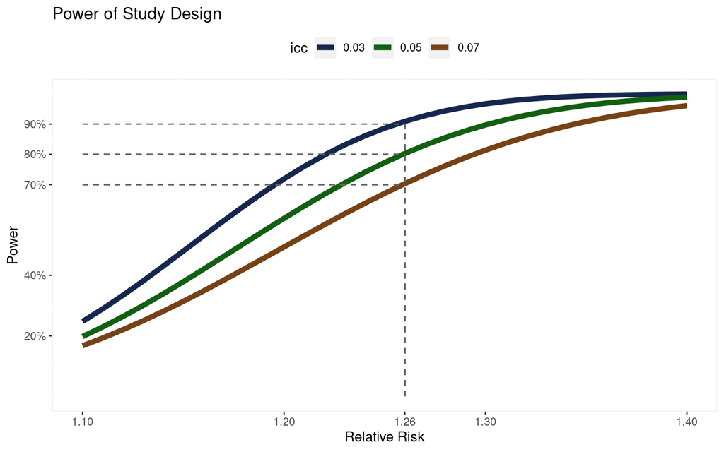

```r
p1 <- 0.65
rr <- seq(1.1,1.4,0.01)
c <- c(14)
n <- 27
icc <- c(0.03,0.05,0.07)
alpha <- c(0.05)
df <- expand.grid(n,p1,rr,c,icc,alpha)
df <- as.data.table(as.data.frame(df))
colnames(df) <- c("n","p1","rr","c","icc","alpha")

# k is calculated on p1
df <- df[
  ,p2 := p1*rr
][p2 < 0.95
][,k := sqrt(icc*(1-p1)/p1)
][,z_alpha := qnorm(1-alpha/2)
][,z_beta := sqrt((c - 2)*(p1-p2)^2/(p1*(1-p1)/n + p2*(1-p2)/n + k^2*(p1^2 + p2^2))) - z_alpha
# ][z_beta > 0
][,power:= pnorm(z_beta)
]
# dim(df)
# [,ni := (qnorm(1-0.05/2) + qnorm(0.8))^2*(p1*(1-p1) + p2*(1-p2))/(p1-p2)^2
# ][,deff := n*c/ni
# ][,deff2 := 2 + icc*(n-1)
# ][power >= 0.8
# ][,diff := power - 0.8
# ][order(c,n,p1,rr,icc,abs(diff))
# ][,rnb := 1:.N,by=list(c,n,p1,rr,icc)
# ][rnb == 1
# ][order(c,p1,rr,icc,n)
# ][,rnb2 :=1:.N,by=list(c,p1,rr,icc)
# ][rnb2 == 1
# ][order(p1,rr,icc,n,c)
# ][,rn:=1:.N]

# View(df) dim(df)
df$alpha <- factor(df$alpha)
df$icc <- factor(df$icc)
df_p80 <- as.data.frame(cbind(x1=0,y1=0.8,x2=1.26,y2=0.8))
# colnames(df_p80)

Color.Line <- "#666666"

p <- ggplot(data=df, aes(x=rr, y=power, group = icc, colour = icc))
p <- p + geom_line(size=2)
p <- p + geom_segment(aes(x = 1.26
                          , y = 0
                          , xend = 1.26
                          , yend = 0.90),linetype=2,colour= Color.Line)
p <- p + geom_segment(aes(x = 1.1
                          , y = 0.7
                          , xend = 1.26
                          , yend = 0.7),linetype=2,colour= Color.Line)
p <- p + geom_segment(aes(x = 1.1
                          , y = 0.8
                          , xend = 1.26
                          , yend = 0.8),linetype=2,colour= Color.Line)
p <- p + geom_segment(aes(x = 1.1
                          , y = 0.9
                          , xend = 1.26
                          , yend = 0.9),linetype=2,colour= Color.Line)
p <- p + labs(x = "Relative Risk"
              ,y="Power"
              ,title="Power of Study Design"
              )
p <- p + scale_colour_manual(values=c("#15274F","#115F11","#764115"))
p <- p + scale_x_continuous(breaks=c(1.1,1.2,1.26,1.3,1.4))
p <- p + scale_y_continuous(breaks=c(0.2,0.4,0.7,0.8,0.9)
                            ,labels = c("20%","40%","70%","80%","90%"))
p <- p + theme(legend.position="top")
p <- p + theme(panel.background = element_rect(fill = '#FFFFFF'
                                               , colour = '#EEEEEE'))
p
```

# Power on Harzard

With design effect 1.1 on the control arm and design effect 1.4, 1.5, and 1.6 on the treatment arm, we calucalte power for the allocation of 124 on the control arm and 168 on the treatment arm, assuming 20% - 50% reduction on hazard (HR 0.8 to 0.5) for the treatment arm, and the proportion of LTFU for the control arm 20%, 30%, or 40%.

- HR: Hazard Ratio
- n_0, n_1, & n_total: Number of participants on the individual arm, group arm, and total
- L_0, L_1, & L: Number of Events from individual PrEP arm, group arm, and total
- pi_0: Proportion of LTFU on the individual PrEP arm
- rho_0 and rho_1: ICC
- deff_0 and deff_1: Design effect
- Power

```r
m <- 3
n_0 <- 124
n_1 <- 168
n_total <- n_0 + n_1
pi_0 <- c(0.2,0.3,0.4)
HR <- c(0.5,0.6,0.7,0.8)
rho_0 <- 0.05
rho_1 <- c(0.2,0.25,0.3)

grd <- as.data.frame(expand.grid(HR,pi_0,rho_0,rho_1))
colnames(grd) <- c("HR","pi_0","rho_0","rho_1")
grd <- grd[order(grd$HR,grd$pi_0,grd$rho_0,grd$rho_1),]

HR <- grd$HR
pi_0 <- grd$pi_0
rho_0 <- grd$rho_0
rho_1 <- grd$rho_1

deff_0 <- 1 + (m-1)*rho_0
deff_1 <- 1 + (m-1)*rho_1

pi_1 <- pi_0*HR

n_0_s <- floor(n_0/deff_0)
n_1_s <- floor(n_1/deff_1)
pi_a <- n_0_s/(n_0_s + n_1_s)
pi_b <- n_1_s/(n_0_s + n_1_s)

L_0 <- n_0_s*pi_0
L_0 <- floor(L_0)
L_1 <- n_1_s*pi_1
L_1 <- floor(L_1)
L <- L_0 + L_1



alpha<-.05
Power <- pnorm(sqrt(pi_a*pi_b*L)*abs(log(HR)) - qnorm(1-alpha/2))
RowNumber <- 1:length(Power)

PCoxH <- as.data.frame(cbind(RowNumber, HR, pi_0
                             ,n_0, n_0_s,L_0
                             ,n_1,rho_1,deff_1,n_1_s,L_1
                             ,L,Power))
knitr::kable(
  PCoxH
  ,digits = 2
)
```

| RowNumber | HR | pi_0 | n_0 | n_0_s | L_0 | n_1 | rho_1 | deff_1 | n_1_s | L_1 | L | Power |
| --- | --- | --- | --- | --- | --- | --- | --- | --- | --- | --- | --- | --- |
| 1 | 0.5 | 0.2 | 124 | 112 | 22 | 168 | 0.20 | 1.4 | 120 | 12 | 34 | 0.52 |
| 2 | 0.5 | 0.2 | 124 | 112 | 22 | 168 | 0.25 | 1.5 | 112 | 11 | 33 | 0.51 |
| 3 | 0.5 | 0.2 | 124 | 112 | 22 | 168 | 0.30 | 1.6 | 105 | 10 | 32 | 0.50 |
| 4 | 0.5 | 0.3 | 124 | 112 | 33 | 168 | 0.20 | 1.4 | 120 | 18 | 51 | 0.70 |
| 5 | 0.5 | 0.3 | 124 | 112 | 33 | 168 | 0.25 | 1.5 | 112 | 16 | 49 | 0.68 |
| 6 | 0.5 | 0.3 | 124 | 112 | 33 | 168 | 0.30 | 1.6 | 105 | 15 | 48 | 0.67 |
| 7 | 0.5 | 0.4 | 124 | 112 | 44 | 168 | 0.20 | 1.4 | 120 | 24 | 68 | 0.81 |
| 8 | 0.5 | 0.4 | 124 | 112 | 44 | 168 | 0.25 | 1.5 | 112 | 22 | 66 | 0.80 |
| 9 | 0.5 | 0.4 | 124 | 112 | 44 | 168 | 0.30 | 1.6 | 105 | 21 | 65 | 0.80 |
| 10 | 0.6 | 0.2 | 124 | 112 | 22 | 168 | 0.20 | 1.4 | 120 | 14 | 36 | 0.33 |
| 11 | 0.6 | 0.2 | 124 | 112 | 22 | 168 | 0.25 | 1.5 | 112 | 13 | 35 | 0.33 |
| 12 | 0.6 | 0.2 | 124 | 112 | 22 | 168 | 0.30 | 1.6 | 105 | 12 | 34 | 0.32 |
| 13 | 0.6 | 0.3 | 124 | 112 | 33 | 168 | 0.20 | 1.4 | 120 | 21 | 54 | 0.47 |
| 14 | 0.6 | 0.3 | 124 | 112 | 33 | 168 | 0.25 | 1.5 | 112 | 20 | 53 | 0.46 |
| 15 | 0.6 | 0.3 | 124 | 112 | 33 | 168 | 0.30 | 1.6 | 105 | 18 | 51 | 0.45 |
| 16 | 0.6 | 0.4 | 124 | 112 | 44 | 168 | 0.20 | 1.4 | 120 | 28 | 72 | 0.58 |
| 17 | 0.6 | 0.4 | 124 | 112 | 44 | 168 | 0.25 | 1.5 | 112 | 26 | 70 | 0.57 |
| 18 | 0.6 | 0.4 | 124 | 112 | 44 | 168 | 0.30 | 1.6 | 105 | 25 | 69 | 0.56 |
| 19 | 0.7 | 0.2 | 124 | 112 | 22 | 168 | 0.20 | 1.4 | 120 | 16 | 38 | 0.19 |
| 20 | 0.7 | 0.2 | 124 | 112 | 22 | 168 | 0.25 | 1.5 | 112 | 15 | 37 | 0.19 |
| 21 | 0.7 | 0.2 | 124 | 112 | 22 | 168 | 0.30 | 1.6 | 105 | 14 | 36 | 0.19 |
| 22 | 0.7 | 0.3 | 124 | 112 | 33 | 168 | 0.20 | 1.4 | 120 | 25 | 58 | 0.27 |
| 23 | 0.7 | 0.3 | 124 | 112 | 33 | 168 | 0.25 | 1.5 | 112 | 23 | 56 | 0.27 |
| 24 | 0.7 | 0.3 | 124 | 112 | 33 | 168 | 0.30 | 1.6 | 105 | 22 | 55 | 0.26 |
| 25 | 0.7 | 0.4 | 124 | 112 | 44 | 168 | 0.20 | 1.4 | 120 | 33 | 77 | 0.35 |
| 26 | 0.7 | 0.4 | 124 | 112 | 44 | 168 | 0.25 | 1.5 | 112 | 31 | 75 | 0.34 |
| 27 | 0.7 | 0.4 | 124 | 112 | 44 | 168 | 0.30 | 1.6 | 105 | 29 | 73 | 0.33 |
| 28 | 0.8 | 0.2 | 124 | 112 | 22 | 168 | 0.20 | 1.4 | 120 | 19 | 41 | 0.11 |
| 29 | 0.8 | 0.2 | 124 | 112 | 22 | 168 | 0.25 | 1.5 | 112 | 17 | 39 | 0.10 |
| 30 | 0.8 | 0.2 | 124 | 112 | 22 | 168 | 0.30 | 1.6 | 105 | 16 | 38 | 0.10 |
| 31 | 0.8 | 0.3 | 124 | 112 | 33 | 168 | 0.20 | 1.4 | 120 | 28 | 61 | 0.14 |
| 32 | 0.8 | 0.3 | 124 | 112 | 33 | 168 | 0.25 | 1.5 | 112 | 26 | 59 | 0.14 |
| 33 | 0.8 | 0.3 | 124 | 112 | 33 | 168 | 0.30 | 1.6 | 105 | 25 | 58 | 0.13 |
| 34 | 0.8 | 0.4 | 124 | 112 | 44 | 168 | 0.20 | 1.4 | 120 | 38 | 82 | 0.17 |
| 35 | 0.8 | 0.4 | 124 | 112 | 44 | 168 | 0.25 | 1.5 | 112 | 35 | 79 | 0.17 |
| 36 | 0.8 | 0.4 | 124 | 112 | 44 | 168 | 0.30 | 1.6 | 105 | 33 | 77 | 0.16 |

```r
m1 <- log(1/2)/log(1-0.4)
m2 <- log(1/2)/log(1 - 0.4*0.5)
library(powerSurvEpi)
pw <- powerCT.default(nE = 120
                , nC = 112
                , pE = 0.28
                , pC = 0.4
                , RR = 0.7
                , alpha = 0.05)
```

# Count Negative Binomial

$$P(X=x) = \binom{x+r-1}{x}p^r(1-p)^x$$

$$\mu = \frac{r(1-p)}{p}$$

$$p = \frac{r}{u+r}$$

$$\sigma^2 = \frac{r(1-p)}{p^2}$$
$$\sigma^2 = \mu + \frac{\mu^2}{r}$$
$$r = \frac{\mu^2}{\sigma^2-\mu}$$

$$Deff = 1 + (m-1)\rho$$

All participants will be followed up for 15 months, and their monthly exposures will be recorded. The way negative binomial works is that there exists significant large difference across individual healers. we assume that even though most of variance on exposure is due to individual practice pattern, some of variance should be due to seasonal and other monthly factors. Therefore conservatively we assume 60% to 80% (70% in average) of variance is due to individual practice pattern, with 15 repeated measures on each participant, we will expect a design effect of 10.8.

```r
library(MASS)
ng_power <- function(eff){
  set.seed(654321)
  for(rep in 1:1000) {
    # print(rep)
    n <- 90*1.388889
    r_week <- 0.075
    mu_week <- 0.88
    p <- r_week/(r_week+mu_week)
    mu_month <- mu_week*4.36
    r_month <- mu_month*p/(1-p)
    size <- r_month

    # rnbinom(n=103,size=0.06852744,prob=0.07206736)
    S_c <- rnbinom(
      n = n
      , size = size
      # , prob = p
      , mu = mu_month
      )
    S_t <- rnbinom(
      n = n
      , size = size
      # , prob = p*eff
      , mu = mu_month*eff
      )

    d1 <- rbind(
      data.frame(count=S_c,treatment=0)
      ,data.frame(count=S_t,treatment=1))
    M1 <- glm.nb(
      count ~ treatment
      ,data = d1
    )
    SM1 <- summary(M1)
    SM1 <- SM1[["coefficients"]]
    p1 <- SM1[2,4]
    p2 <- p1 < 0.01
    p1 <- p1 < 0.05
    if(rep==1){pv <- p1}else{pv <- c(pv,p1)}

    if(rep==1){pv2 <- p2}else{pv2 <- c(pv2,p2)}
    # return(pv)
  }
  return(c(sum(pv)/length(pv),sum(pv2)/length(pv)))
}

seq_eff <- seq(0.4,0.8,by=0.025)
# x <- ng_power(0.5)
## length(seq_eff)

power_exp <- data.frame(
  reduction = seq_eff
  ,power = rbind(
    ng_power(seq_eff[1])
    ,ng_power(seq_eff[2])
    ,ng_power(seq_eff[3])
    ,ng_power(seq_eff[4])
    ,ng_power(seq_eff[5])
    ,ng_power(seq_eff[6])
    ,ng_power(seq_eff[7])
    ,ng_power(seq_eff[8])
    ,ng_power(seq_eff[9])
    ,ng_power(seq_eff[10])
    ,ng_power(seq_eff[11])
    ,ng_power(seq_eff[12])
    ,ng_power(seq_eff[13])
    ,ng_power(seq_eff[14])
    ,ng_power(seq_eff[15])
    ,ng_power(seq_eff[16])
    ,ng_power(seq_eff[17])
  )
)


power_exp$reduction <- WuPercent(power_exp$reduction,1)
power_exp$power.1 <- WuPercent(power_exp$power.1,1)
power_exp$power.2 <- WuPercent(power_exp$power.2,1)

knitr::kable(
  power_exp
  ,caption = "Power Calculation for Blood Exposure, 90 per arm"
  ,col.names = c("Rate Ratio","Power with 5% Type I Error", "Power with 1% Type I Error")
  ,align = c("r","r","r")
)
```

[output not shown]

R version 4.2.0 (2022-04-22) Platform: x86_64-pc-linux-gnu (64-bit) Running under: Ubuntu 20.04.3 LTS

Matrix products: default BLAS: /usr/lib/x86_64-linux-gnu/blas/libblas.so.3.9.0 LAPACK: /usr/lib/x86_64-linux-gnu/lapack/liblapack.so.3.9.0

locale: [1] LC_CTYPE=C.UTF-8 LC_NUMERIC=C LC_TIME=C.UTF-8  
[4] LC_COLLATE=C.UTF-8 LC_MONETARY=C.UTF-8 LC_MESSAGES=C.UTF-8  
[7] LC_PAPER=C.UTF-8 LC_NAME=C LC_ADDRESS=C  
[10] LC_TELEPHONE=C LC_MEASUREMENT=C.UTF-8 LC_IDENTIFICATION=C

attached base packages: [1] stats graphics grDevices utils datasets methods base